# R Notebook midterm: 419 Survey of Multivariate Methods

### Understanding the `cutree`

In the above example, the tree was cut into 12 groups based on the “distance” formula used and based on the “agglomeration” linkage technique invoice. I likely should have used a “geo-spatial” distance, but we will see that mere “euclidean” distance seems to perform okay.

A fancy word for this statistical tree is a “dendrogram”. I call each element of the tree a branch. The smallest branches (twigs) are the fundamental elements, in this case the cities. Over time, they merge with other small branches, and so on.

The relative height when this smallest branch merges with another branch demonstrates when the branch has found a similar pair-wise match (with another smallest branch or a merging branch). I call “Honolulu Hawaii” an isolate because the vertical height when it merges with another branch is the highest of all of the smallest branches (e.g., cities). “Juneau Alaska” is another isolate, but it does merge before “Hawaii”.

It would be nice if we could decompose this information and look at one `cutree` at a time. And color-code the distinctions. Using the function `plot.hclust.sub` we can do this.

```r
source_url( paste0(path.github,"humanVerseWSU/R/functions-EDA.R") );  # EDA functions ...
```

```
## SHA-1 hash of file is dd72e464241952b23d5b08d2213099eccf7a86f6
```

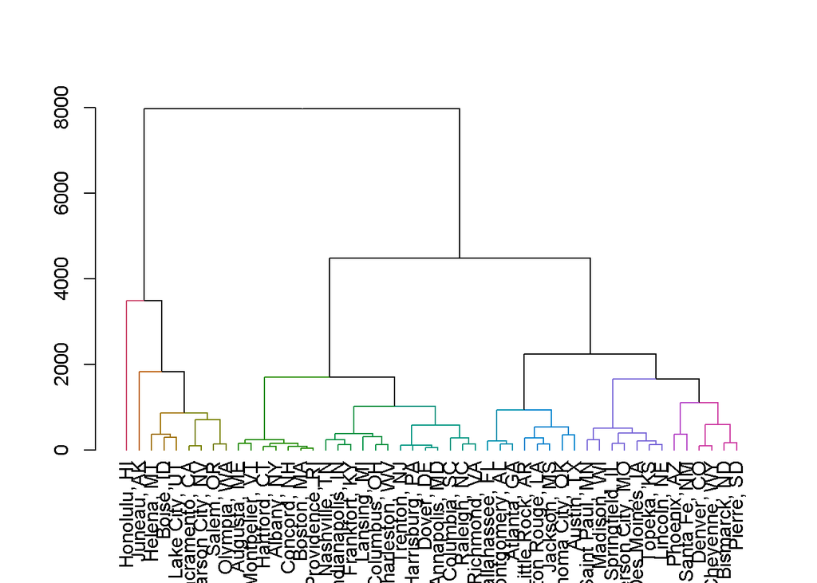

```
## [1] "Pruning 1 of 12"
## [1] "Pruning 2 of 12"
## [1] "Pruning 3 of 12"
## [1] "Pruning 4 of 12"
## [1] "Pruning 5 of 12"
## [1] "Pruning 6 of 12"
## [1] "Pruning 7 of 12"
## [1] "Pruning 8 of 12"
## [1] "Pruning 9 of 12"
## [1] "Pruning 10 of 12"
## [1] "Pruning 11 of 12"
## [1] "Pruning 12 of 12"
```

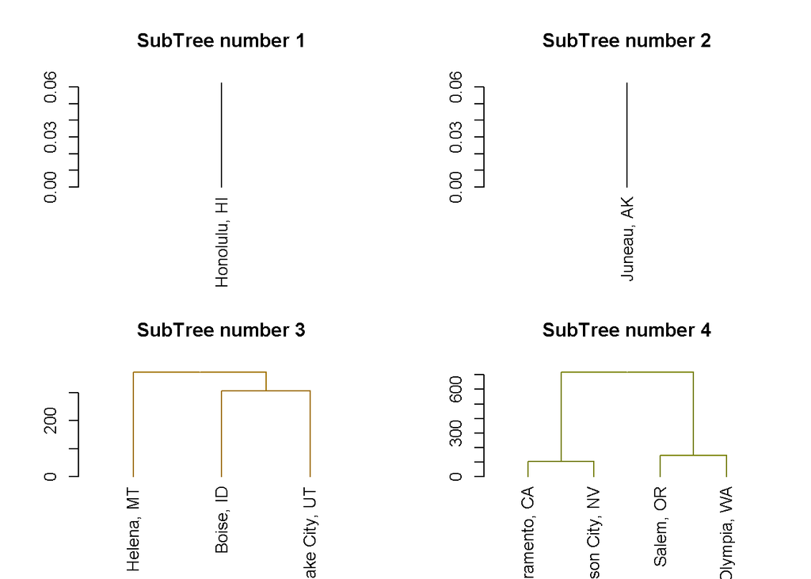

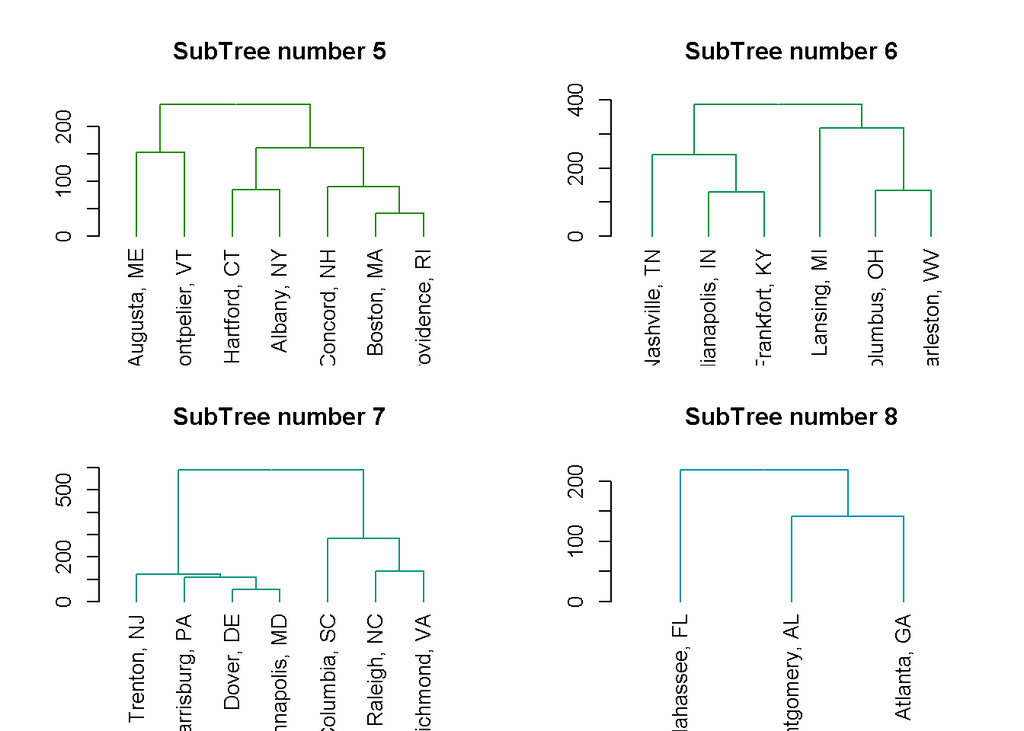

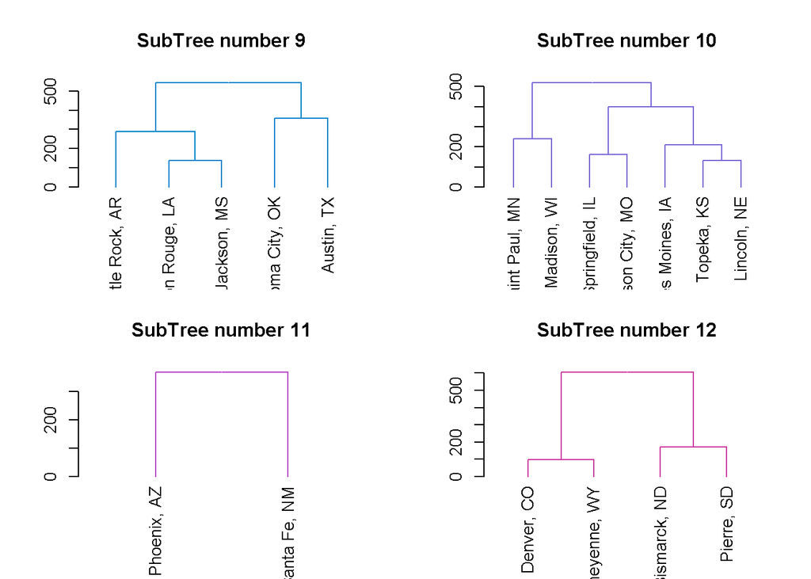

```r
hclust.ward2.dist.euclidean$labels = myLabels;
plot.hclust.sub(hclust.ward2.dist.euclidean, k=12);
```

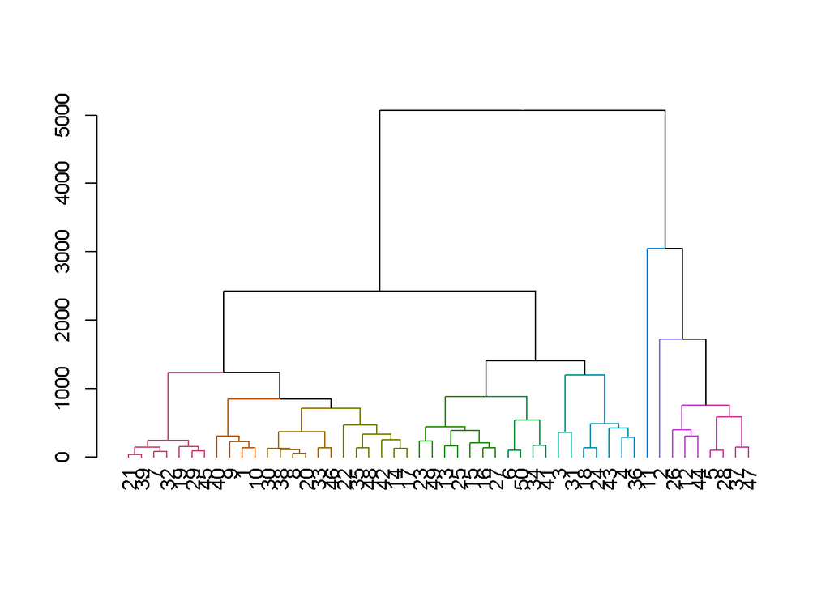

```
## [1] "Pruning 1 of 12"
## [1] "Pruning 2 of 12"
## [1] "Pruning 3 of 12"
## [1] "Pruning 4 of 12"
## [1] "Pruning 5 of 12"
## [1] "Pruning 6 of 12"
## [1] "Pruning 7 of 12"
## [1] "Pruning 8 of 12"
## [1] "Pruning 9 of 12"
## [1] "Pruning 10 of 12"
## [1] "Pruning 11 of 12"
## [1] "Pruning 12 of 12"
```

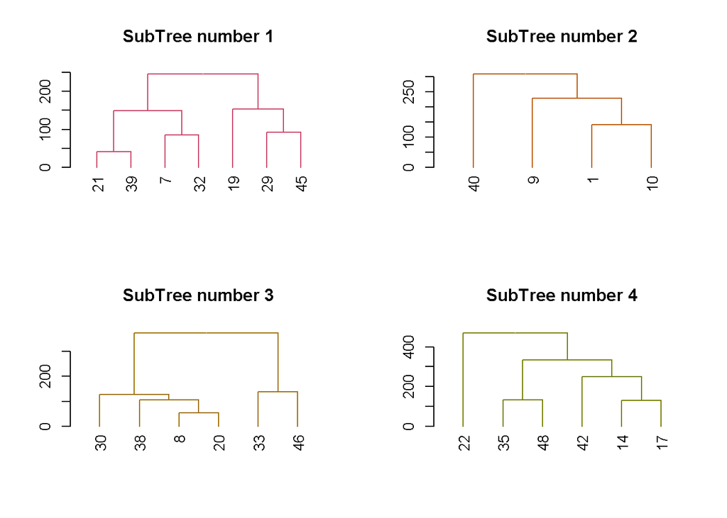

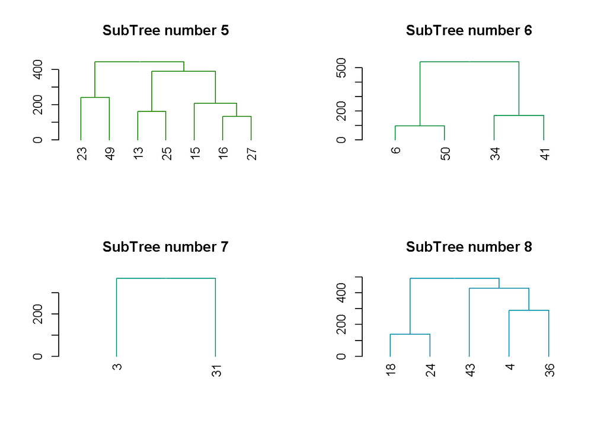

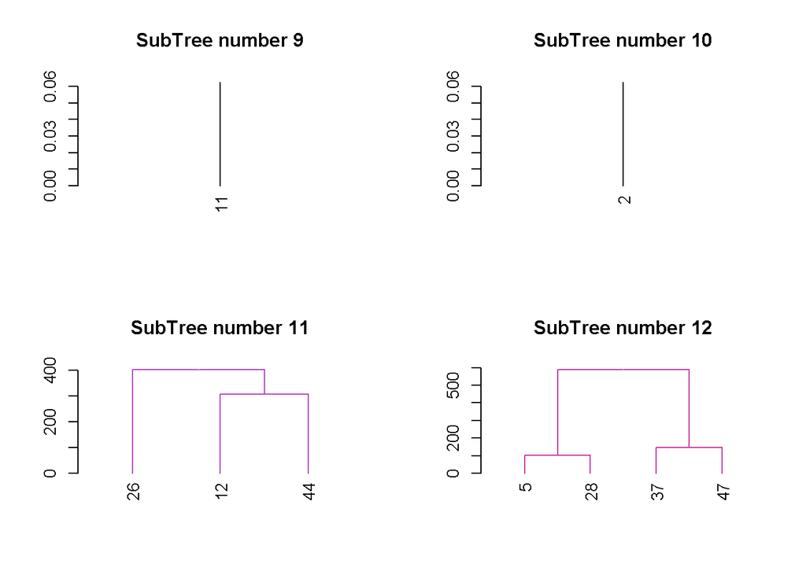

```r
plot.hclust.sub(hclust.complete.dist.euclidean, k=12);
```

### (10 points) Review one clustering tree (dendrogram)

Choose either `hclust.ward2.dist.euclidean` or `hclust.complete.dist.euclidean` and review how the U.S. state capitals are clustered. [I commented out one form, so you will have to re-run if you want to select that one.]

Comment on the “face validity” of this approach based on your understanding about how the U.S. regions are defined? Are the North/South Dakotas together? What about the North/South Carolinas? What about the Pacific Northwest? While living in Kentucky, some people called the area “Kentuckiana” meaning Kentucky/Indiana. Does that show up? Also note anything that seems peculiar.

```
-- WRITE SOMETHING HERE --
I used hclust.ward2.dist.euclidean because the subtrees were labelled names as opposed to numbers (I choose the easiest/lazy option).

I think that hierarchial clustering based on distance is a good way to divide the United States without further research (basing my knowledge of US regions from memory--which, sadly, I have a terrible memory). North and South Dakota are clustered together. It did cluster Kentucky and Indiana as the closest subtree.

In my head these are the regions of the US: Pacific Northwest, Southwest, Texas, South, Northeastern States, East Coast, Dust Bowl, West, and maybe Florida, plus Alaska, and Hawaii.  Both Florida and Texas are weird standalone states that should be lumped into "South", but I don't. Of course, these are from my memory, and I admit I am weakest in my knowledge of most of the middle of the US in between the two coasts and their immediate neighboring states.

In the South: North and South Carolinas are clustered together, but the closest subtree is NC and VA together, not NC and SC -- which does make sense. In my head, North Carolina is not a part of the South. I grew up outside of Philadelphia, and I consider North Carolina and Virginia to be borderline Northern States, but South Carolina is firmly "Southern". When my husband (I apologize that I pepper my responses with him, but I am a pretty isolated stay-at-home mother and I definitely need to get out more (that will be when I graduate and get a job hopefully)!!) was considering looking for another company out of Tucson, I told him "anywhere except the Dust Bowl and the South".  He interviewed for a company in North Carolina -- which I never considered "South"! To me, the "South" is Alabama, Louisiana, Georgia, South Carolina, Louisiana, Missouri, and Arkansas, with Florida being another "borderline South" state like North Carolina. The tree did not ballpark the "South" very well.

In the Pacific Northwest: The tree pinpointed what I consider the Pacific Northwest, mostly accurately.  It did include Nevada (which makes sense in terms of distance but not in terms of traditional US regions).

In the Northeastern States: Subtree #5 did a good job of what I would consider "Northeastern States".

In the East Coast: Subtree #7 also did a good job of what I consider "East Coast States".  The only exception is New York, which is placed in the Northeastern States.  In my head, New York, NY is the "real" capital and it is closer to Philadelphia and New Jersey than Albany is.

I can't really comment too much about the middle of America states and the tree's accuracy.  I've always lived on an outer edge of the US my whole life -- born in Texas, lived in Florida and Philadelphia, then Arizona, and now California.
```

### Additional remarks about `hclust`

I find `hclust` to be a nice initial perusal of the data.

If you want to understand the stability of a particular `hclust` to use it for something other than an “initial perusal of the data,” I would recommend `pvclust` which I introduced in the weekly notebooks. It is often used in peer-reviewed research, as it provides a `p-value` of sorts regarding the **stability** of the `hclust` structure.

## GENERIC clustering

Aggregating or agglomerating data is typically called “clustering”. In exploration, we can create some generic clustering techniques. Below we will create two adhoc clustering rules.

### Arbitrary Aggregation

Recall the “movie dataset” with “Will Smith” and “Denzel Washington”. We have a collection of movies, and how much money each movie made at the box office. We could organize those movies by some arbitrary rules. For example:

- Cluster 1: NA. We have missing data regarding the money. So let’s put all movies that are NA into that cluster.
- Cluster 2: Under a million dollars
- Cluster 3: 1-4.99… million dollars (greater than or equal to one, but less than 5)
- Cluster 4: 5-49.99…
- Cluster 5: 50+

#### (5 points) Movie Aggregation [Arbitrary] for Will and Denzel

```r
library(devtools);
source_url( paste0(path.mshaffer, "will") );
```

```
## SHA-1 hash of file is 3c1c97d961577e9b47a12faa20dca74bfe755c87
```

```r
source_url( paste0(path.mshaffer, "denzel") );
```

```
## SHA-1 hash of file is 6692d8c5629db1ae023691bb55de2664a48cdde0
```

```r
movies.50 = rbind(will$movies.50, denzel$movies.50);

unique(movies.50$ttid); # are they in any shared movies ???
```

```
##   [1] "tt0480249" "tt1386697" "tt0116629" "tt0119654" "tt0343818" "tt0454921"
##   [7] "tt0448157" "tt0120912" "tt1409024" "tt0386588" "tt0814314" "tt0112442"
##  [13] "tt0172156" "tt0120660" "tt6139732" "tt0145660" "tt2381941" "tt1815862"
##  [19] "tt1596350" "tt1229340" "tt5519340" "tt0307453" "tt1155076" "tt0120891"
##  [25] "tt0120783" "tt1502397" "tt0248667" "tt4682786" "tt3322364" "tt1025100"
##  [31] "tt0114558" "tt0300051" "tt0284490" "tt0146984" "tt1837709" "tt0338466"
##  [37] "tt0947802" "tt1823664" "tt0268397" "tt1082886" "tt5814534" "tt3721964"
##  [43] "tt0416212" "tt0108149" "tt0328099" "tt0167427" "tt0466839" "tt0107478"
##  [49] "tt7255568" "tt0466856" "tt0765429" "tt0139654" "tt0454848" "tt0455944"
##  [55] "tt0328107" "tt1907668" "tt0453467" "tt1037705" "tt0107818" "tt1599348"
##  [61] "tt0210945" "tt1272878" "tt1111422" "tt0477080" "tt2404435" "tt0145681"
##  [67] "tt3766354" "tt0251160" "tt0097441" "tt0368008" "tt0112740" "tt2671706"
##  [73] "tt0174856" "tt0104797" "tt0107798" "tt0119099" "tt0133952" "tt0313443"
##  [79] "tt0427309" "tt0115956" "tt0107616" "tt0124718" "tt0168786" "tt6000478"
##  [85] "tt0114857" "tt0112857" "tt0102789" "tt0092804" "tt0100168" "tt0117372"
##  [91] "tt0088146" "tt0097880" "tt0102456" "tt0099750" "tt0091786" "tt0082138"
##  [97] "tt0097373" "tt4283892" "tt1698652" "tt0118783"
```

```r
loadInflationData();

movies.50 = standardizeDollarsInDataFrame(movies.50,
                2000,
                "millions",
                "year",
                "millionsAdj2000");

movies.50$cluster.arbitrary = NA;
str(movies.50);
```

```
## 'data.frame':    100 obs. of  13 variables:
##  $ rank             : num  1 2 3 4 5 6 7 8 9 10 ...
##  $ title            : chr  "I Am Legend" "Suicide Squad" "Independence Day" "Men in Black" ...
##  $ ttid             : chr  "tt0480249" "tt1386697" "tt0116629" "tt0119654" ...
##  $ year             : num  2007 2016 1996 1997 2004 ...
##  $ rated            : chr  "PG-13" "PG-13" "PG-13" "PG-13" ...
##  $ minutes          : num  101 123 145 98 115 117 92 88 106 118 ...
##  $ genre            : chr  "Action, Adventure, Drama" "Action, Adventure, Fantasy" "Action, Adventure, Sci-Fi" "Action, Adventure, Comedy" ...
##  $ ratings          : num  7.2 6 7 7.3 7.1 8 6.4 6.2 6.8 6.6 ...
##  $ metacritic       : num  65 40 59 71 59 64 49 49 58 58 ...
##  $ votes            : num  675193 588111 520657 507618 491489 ...
##  $ millions         : num  256 325 306 251 145 ...
##  $ millionsAdj2000  : num  213 233 336 269 132 ...
##  $ cluster.arbitrary: logi  NA NA NA NA NA NA ...
```

```r
## you do something here ...

# (1) populate cluster.arbitrary
##need to find and replace according to cluster category

for (i in 1:length(movies.50$millionsAdj2000))
{
  if(is.na(movies.50$millionsAdj2000[i]))
  {
    movies.50$cluster.arbitrary[i] = 1
  }
  else if(movies.50$millionsAdj2000[i] < 1)
  {
    movies.50$cluster.arbitrary[i] = 2
  }
  else if(movies.50$millionsAdj2000[i] < 5)
  {
    movies.50$cluster.arbitrary[i] = 3
  }
  else if(movies.50$millionsAdj2000[i] < 50)
  {
    movies.50$cluster.arbitrary[i] = 4
  }
    else
  {
    movies.50$cluster.arbitrary[i] = 5
  }
}
# (2) summarize how many movies live in each (table count)
library(plyr)
cluster_count = count(movies.50, vars = "cluster.arbitrary" )

cluster_count
```

| cluster.arbitrary | freq |
| --- | --- |
| 1 | 5 |
| 2 | 4 |
| 3 | 2 |
| 4 | 38 |
| 5 | 51 |

[output not shown]

### Aggregating using Quantiles

John Tukey emphasized that ordering the data and then splitting it based on the ordering was a fundamental premise of exploratory data analysis.

#### Tukey’s Summary Data

John Tukey proposed five elements as primary data for analysis.

- the minimum `min`
- the maximum `max`

Sorting the data makes it easiest to find these data, and will be useful to find the other three exploratory summary features.

This is what I would call “slice and dice”. The data is cut in half, and the value of that middle “cutting point” is the `Q2` which we call the `median`.

Next, the lower half could also be cut in half, and the value of that middle “cutting” point is `Q1`.

Then, the upper half could also be cut in half, and the value of that middle “cutting” point is `Q3`.

A common metric derived from this “median-split” procedure is called the interquartile range `IQR` which is defined as the distance between `Q3` and `Q1`. It literally represents the middle 50% of the data; 50% of the elements of the dataset are between `Q3` and `Q1`.

#### Quartile Example

```r
x = 1:99;
length(x);
```

```
## [1] 99
```

```r
median(x);
```

```
## [1] 50
```

```r
x[50];
```

```
## [1] 50
```

```r
median(x[1:49]);
```

```
## [1] 25
```

```r
x[25];
```

```
## [1] 25
```

```r
median(x[51:99]);
```

```
## [1] 75
```

```r
x[75];
```

```
## [1] 75
```

```r
# probability-approach ...
# algorithm: the default type=7
stats::quantile(x, prob = c(0.25, 0.5, 0.75), type=1);
```

```
## 25% 50% 75%
##  25  50  75
```

Algorithms address various issues associated with dividing numbers and whether or not to include the dividing number in the subset division, but the principle holds.

We can generalize this idea by not always cutting the data in half (median-split as `n=2`, median-median-split as `n=4`). Instead, we could cut by tens (we call them deciles). Or we could cut by hundreds (we call them centiles). The function `quantile` performs this operation, and if you dig into the `doStatsSummary` function used in this course, you can see its application.

#### (5 points) Movie Aggregation [Decile] for Will and Denzel

```r
movies.50$cluster.deciles = NA;
str(movies.50);
```

```
## 'data.frame':    100 obs. of  14 variables:
##  $ rank             : num  1 2 3 4 5 6 7 8 9 10 ...
##  $ title            : chr  "I Am Legend" "Suicide Squad" "Independence Day" "Men in Black" ...
##  $ ttid             : chr  "tt0480249" "tt1386697" "tt0116629" "tt0119654" ...
##  $ year             : num  2007 2016 1996 1997 2004 ...
##  $ rated            : chr  "PG-13" "PG-13" "PG-13" "PG-13" ...
##  $ minutes          : num  101 123 145 98 115 117 92 88 106 118 ...
##  $ genre            : chr  "Action, Adventure, Drama" "Action, Adventure, Fantasy" "Action, Adventure, Sci-Fi" "Action, Adventure, Comedy" ...
##  $ ratings          : num  7.2 6 7 7.3 7.1 8 6.4 6.2 6.8 6.6 ...
##  $ metacritic       : num  65 40 59 71 59 64 49 49 58 58 ...
##  $ votes            : num  675193 588111 520657 507618 491489 ...
##  $ millions         : num  256 325 306 251 145 ...
##  $ millionsAdj2000  : num  213 233 336 269 132 ...
##  $ cluster.arbitrary: num  5 5 5 5 5 5 5 5 5 5 ...
##  $ cluster.deciles  : logi  NA NA NA NA NA NA ...
```

```r
## you do something here ...

# use # stats::quantile(x, prob=seq(0.1,0.9,by=0.1), type=1 );
# (1) how many NA's are there ... keep them NA's
# (2) for the rest of the data, break it up into deciles
# (3) $cluster.deciles for a given movie should be NA, 1, 2, 3, ... 10
# (4) summarize how many movies live in each (table count)

vect = quantile(movies.50$millionsAdj2000, prob = seq(.1,.9, by=.1), type=1, na.rm=TRUE)
vect
```

```
##        10%        20%        30%        40%        50%        60%        70%
##   7.638768  20.177743  27.511542  37.259081  53.554796  64.786272  74.509802
##        80%        90%
## 115.650000 146.638920
```

```r
vect[1]
```

```
##      10%
## 7.638768
```

```r
for (i in 1:length(movies.50$millionsAdj2000))
{
  if(is.na(movies.50$millionsAdj2000[i]))
  {
    movies.50$cluster.deciles[i] = NA
  }
  else if(movies.50$millionsAdj2000[i] < vect[1])
  {
    movies.50$cluster.deciles[i] = 1
  }
  else if(movies.50$millionsAdj2000[i] < vect[2])
  {
    movies.50$cluster.deciles[i] = 2
  }
  else if(movies.50$millionsAdj2000[i] < vect[3])
  {
    movies.50$cluster.deciles[i] = 3
  }
  else if(movies.50$millionsAdj2000[i] < vect[4])
  {
    movies.50$cluster.deciles[i] = 4
  }
  else if(movies.50$millionsAdj2000[i] < vect[5])
  {
    movies.50$cluster.deciles[i] = 5
  }
  else if(movies.50$millionsAdj2000[i] < vect[6])
  {
    movies.50$cluster.deciles[i] = 6
  }
  else if(movies.50$millionsAdj2000[i] < vect[7])
  {
    movies.50$cluster.deciles[i] = 7
  }
  else if(movies.50$millionsAdj2000[i] < vect[8])
  {
    movies.50$cluster.deciles[i] = 8
  }
  else if(movies.50$millionsAdj2000[i] < vect[9])
  {
    movies.50$cluster.deciles[i] = 9
  }
    else
  {
    movies.50$cluster.deciles[i] = 10
  }
}
# (2) summarize how many movies live in each (table count)
library(plyr)
cluster.deciles_count = count(movies.50, vars = "cluster.deciles" )

cluster.deciles_count
```

| cluster.deciles | freq |
| --- | --- |
| 1 | 9 |
| 2 | 9 |
| 3 | 10 |
| 4 | 9 |
| 5 | 10 |
| 6 | 9 |
| 7 | 10 |
| 8 | 9 |
| 9 | 10 |
| 10 | 10 |

[output cut: 1 more lines]

[output not shown]

## CENTROID clustering (k-means) as a function of distance

### Introduction

Rather than clustering on distance-linkage in a pair-wise fashion, we can cluster based on randomly selecting just `k` points in our data and begin identifying their nearest neighbors using some distance approach.

For example, if `k=3`, we would randomly select three of our data points. We would then compute the distances from all of the remaining points to these `3` anchor points. The points that are closest to a given anchor will be assigned to that anchor. At the end of the stage, we now have new data, so a new centroid is determined. At this point, the centroid https://en.wikipedia.org/wiki/Centroid is likely not one of our data points, but a location within the given centroid cluster. In the “naive” approach, you merely take an average (mean) of all the members of your cluster. More advanced approaches (the default “Hartigan-Wong” of `kmeans`) utilize deviations from the average, called a sum-of-squares approach. This is why in our `kmeans-notebook` we analyzed the `wss` to ascertain how many clusters `k` should we use.

Regardless, after the new centroids (centers) for the clusters are determined, the process iterates. All distances are computed from all points to the new centroids; points are assigned to a given centroid cluster (in this example: 1, 2, 3); a new centroid center is computed, and we repeat the process until a stopping rule is reached: maybe we have exhausted the number of iterations allowed (`iter.max` parameter of `kmeans`)? Or maybe we are not changing membership of any of the data points? Or maybe we have met some objective (like `wss`)?

It is possible to get a `kmeans` result by merely starting with `3 different` random points. In general, `kmeans` is fast (and our computers are so much faster than the computers of 1990: the first computer I built in 1995 had 32MB of RAM, a Pentium processor https://en.wikipedia.org/wiki/Pentium#Pentium and a 900MB Cheetah hard-drive).

Anyway, we can utilize the parameter `nstart` to try many different starting values, and let the program identify the best, most consistent solution.

### My recommendations

I would recommend the default algorithm `Hartigan-Wong` with `iter.max=100` and `nstart=100`. You can test the timings from the default values: `iter.max=10` and `nstart=1`. Since the data is likely multidimensional `stars` are the best way to summary the results and membership of `kmeans`. Please see the “kmeans-notebook” for examples.

### WIKIPEDIA CLIMATE DATA

For the 50 U.S. cities, we harvested climate data. In the “Wikipedia” notebook, details of that data provenance were outlined. If we want to compare the cities using the climate data, we have to build a matching dataframe, which means we have to select features that exist in each city’s climate data set.

There are four temperature features that are always present:

Additionally, for precipitation we have:

- Average precipitation inches (mm) … we will call it “rain”
- Average snowfall inches (cm) … we will call it “snow”

For each of these features we have 12 months of data. This is a nice dataset. Let’s see what we can do with it.

#### Basic Background Research

We should begin by doing a bit of peripheral research on the topic, to gain “domain knowledge” so we know what to do with the data. A few elements that would benefit.

https://www.forbes.com/sites/brianbrettschneider/2018/07/08/when-does-the-hottest-day-of-the-year-usually-occur/#78141f47548c

[figure not shown]

**Source: https://bit.ly/359HAnY**

https://www.climate.gov/news-features/featured-images/whats-coldest-day-year

#### One Graph

When graphing data to visualize, it is essential that you keep the scales uniform so quick-visual comparisons are accurate. I gave you a task to practice the idea of creation that “one informative” research graphic. And I now present my version for you to use and critique based on your efforts. I am a `plot` guy, so some of you may have a different ``ggplot2` type solution. Ultimately, the intent of this graphic is to best summarize the data in a meaninful way for exploratory analysis.

##### (5 points) One Research Graph

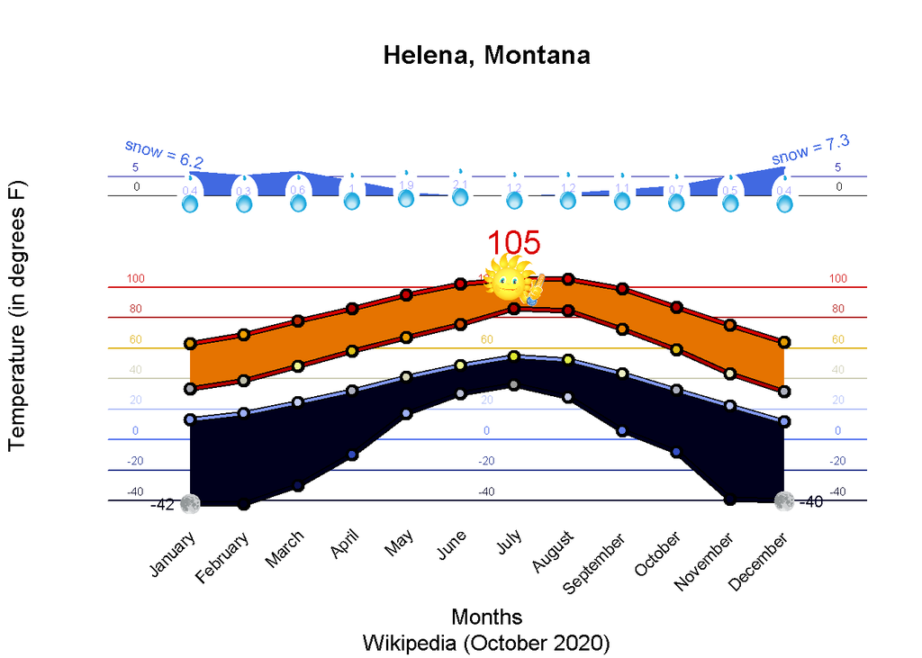

```r
climate = utils::read.csv( paste0(path.mshaffer, "_data_/state-capitals/final/state-capitals-climatedata.txt"), header=TRUE, quote="", sep="|");


plotTemperatureFromWikipediaData(climate, city.key="capital", city.val="Helena");
```

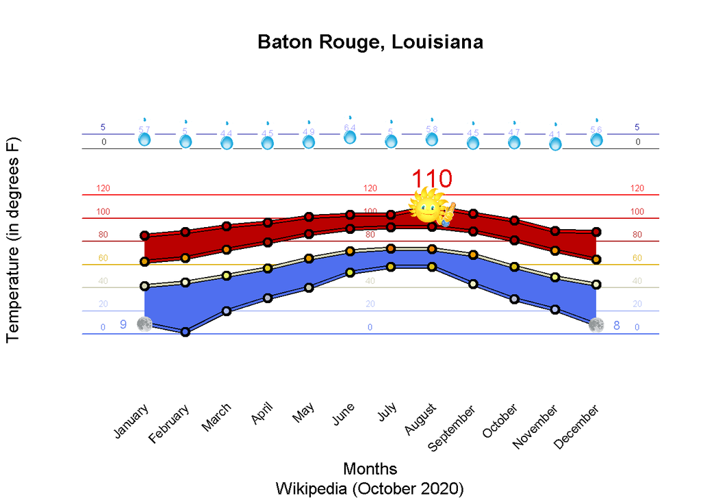

[output not shown]

```r
plotTemperatureFromWikipediaData(climate, city.key="capital", city.val="Baton Rouge");
```

[ What do you like about this graphic?

What do you dislike?

Is it aesthetically pleasing? Is it functional?

]

We can achieve a side-by-side comparison using the function described below. The first city will be graphed on the left, the second city on the right.

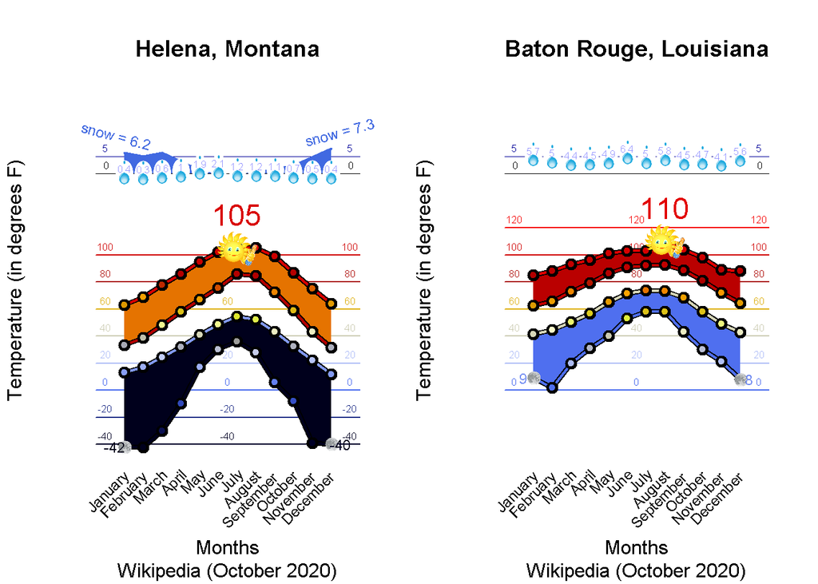

[output not shown]

```r
compareTwoCitiesClimates(climate, city.key="capital", city.1="Helena", city.2="Baton Rouge");
```

[ What do you like about this graphic?

What do you dislike?

Are the y-axis the same scale? Are the visible gridlines for each the same?

What is the difference between rain and snow on the graphic? Was that a good approach? How would you have done it?

]

##### (5 points) One Publication Graph

We are in exploration, so the “one” research graphic may be very different than the “one” formal graphic designed for a client. Typically, the final graphic needs to meet certain criteria:

- Very pleasing aesthetically
- Interactive if possible
- Live data feeds if possible
- Served in a secure, safe, private location (if required by the client)

To demonstrate the differences, I created a mockup of our 50 U.S. cities and put it into a nice finalized product form called “highcharts”.

http://md5.mshaffer.com/WSU_STATS419/_EXAMPLES_/fiddle_usmap/

It pulls data in real time (using AJAX) to grab the weather at the latitudes/longitudes we defined in our Wikipedia notebook.

- You can use your mouse to draw a box to zoom in.
- The third-wheel on the mouse also helps you zoom in/out.
- Hold down CNTRL with your left hand and use your mouse key to drag the map. It seems to only “pan” in the x-direction at the moment.
- The data in the popup displayed can be customized. I report the temperature in Celsius/Fahrenheit and also display the population data we gathered from Wikipedia.

Once you have a template built, it is rather easy to modify it. Here I changed the background map, and all of the data/features stay the same:

http://md5.mshaffer.com/WSU_STATS419/_EXAMPLES_/fiddle_usmap/world.html

### Which Features to Include in the Analysis

- months, you can pick all of them `1:12` or maybe just one month per season (April, July, October, January)
- X, depending on what you chose for months, you can now select what climate columns you want to use
  - Some of Temperature Data
  - All of Temperature Data
  - Precipitation Data
  - Everything (All of Temperature Data, Precipitation Data)

If we want to cluster cities, which decisions seem best? Why? As you can see from the code below, you just comment out two options, and can quickly rerun the analysis.

- WHICH MONTHS
- WHICH COLUMNS

#### WHICH MONTHS & WHICH COLUMNS

```r
climate = utils::read.csv( paste0(path.mshaffer, "_data_/state-capitals/final/state-capitals-climatedata.txt"), header=TRUE, quote=
                             "", sep="|");

##################### WHICH MONTHS #####################
########################################################
months = 1:12; # all the data
#months = c(1,4,7,10); # one month of each of the four seasons
########################################################


month.abb;  # ?month.abb
```

```
##  [1] "Jan" "Feb" "Mar" "Apr" "May" "Jun" "Jul" "Aug" "Sep" "Oct" "Nov" "Dec"
```

```r
month.name;
```

```
##  [1] "January"   "February"  "March"     "April"     "May"       "June"
##  [7] "July"      "August"    "September" "October"   "November"  "December"
```

```r
month.name[months];  # these are the names of the months you are selecting ...
```

```
##  [1] "January"   "February"  "March"     "April"     "May"       "June"
##  [7] "July"      "August"    "September" "October"   "November"  "December"
```

```r
# this function would allow us to use different months as criteria and different climate-data keys.  It is variadic and flexible.  `key.n` are the names we will use for our new columns ...

climate.df = buildClimateDataFrame(climate, months, keys=c("Record high F (C)", "Average high F (C)", "Average low F (C)", "Record low F (C)", "Average precipitation inches (mm)", "Average snowfall inches (cm)"), keys.n = c("highmax", "highavg",  "lowavg", "lowmin", "rain", "snow") );

climate.df;
```

|  | state | capital | st | labels | highmax.Jan | highmax.Feb | highmax.Mar | highmax.Apr | highmax.May | highmax.Jun | highmax.Jul | highmax.Aug | highmax.Sep | highmax.Oct | highmax.Nov | highmax.Dec | highavg.Jan | highavg.Feb | highavg.Mar | highavg.Apr | highavg.May | highavg.Jun | highavg.Jul | highavg.Aug | highavg.Sep | highavg.Oct | highavg.Nov | highavg.Dec | lowavg.Jan | … |
| --- | --- | --- | --- | --- | --- | --- | --- | --- | --- | --- | --- | --- | --- | --- | --- | --- | --- | --- | --- | --- | --- | --- | --- | --- | --- | --- | --- | --- | --- | --- |
| 1 | Alabama | Montgomery | AL | Montgomery, AL | 83 | 86 | 90 | 94 | 99 | 106 | 107 | 106 | 106 | 102 | 91 | 85 | 57.4 | 61.8 | 69.7 | 76.6 | 84.0 | 89.8 | 92.1 | 91.9 | 87.3 | 78.3 | 69.0 | 59.6 | 35.7 | … |
| 23 | Alaska | Juneau | AK | Juneau, AK | 60 | 57 | 61 | 72 | 80 | 87 | 89 | 87 | 85 | 68 | 64 | 59 | 34.6 | 36.7 | 40.8 | 49.1 | 56.9 | 62.4 | 63.4 | 62.6 | 56.6 | 48.4 | 39.8 | 36.7 | 26.2 | … |
| 39 | Arizona | Phoenix | AZ | Phoenix, AZ | 88 | 92 | 100 | 105 | 114 | 122 | 121 | 117 | 116 | 107 | 96 | 87 | 67.2 | 70.7 | 76.9 | 85.2 | 94.8 | 103.9 | 106.1 | 104.4 | 99.8 | 88.5 | 75.5 | 66.0 | 45.6 | … |
| 59 | Arkansas | Little Rock | AR | Little Rock, AR | 83 | 87 | 91 | 95 | 98 | 107 | 112 | 114 | 106 | 98 | 86 | 81 | 50.5 | 55.1 | 64.0 | 73.1 | 81.1 | 88.9 | 92.5 | 92.6 | 85.6 | 74.8 | 63.0 | 52.3 | 31.2 | … |
| 79 | California | Sacramento | CA | Sacramento, CA | 79 | 80 | 90 | 98 | 107 | 112 | 114 | 112 | 109 | 102 | 86 | 72 | 54.4 | 61.2 | 66.8 | 72.7 | 80.9 | 87.9 | 93.3 | 92.2 | 87.9 | 77.9 | 63.7 | 54.3 | 40.7 | … |
| 94 | Colorado | Denver | CO | Denver, CO | 76 | 80 | 84 | 90 | 95 | 105 | 105 | 105 | 101 | 90 | 81 | 79 | 44.0 | 46.2 | 54.4 | 61.5 | 71.5 | 82.4 | 89.4 | 87.2 | 78.5 | 65.3 | 52.1 | 42.8 | 17.4 | … |
| 117 | Connecticut | Hartford | CT | Hartford, CT | 72 | 77 | 89 | 96 | 99 | 100 | 103 | 102 | 101 | 91 | 83 | 76 | 34.5 | 38.5 | 47.7 | 60.5 | 71.2 | 79.6 | 84.5 | 82.7 | 74.9 | 63.1 | 51.6 | 39.7 | 17.7 | … |
| 141 | Delaware | Dover | DE | Dover, DE | 77 | 80 | 88 | 97 | 98 | 101 | 104 | 102 | 99 | 95 | 85 | 75 | 43.4 | 47.0 | 54.9 | 65.7 | 74.7 | 83.2 | 87.0 | 85.2 | 79.3 | 68.8 | 58.5 | 47.4 | 27.1 | … |
| 162 | Florida | Tallahassee | FL | Tallahassee, FL | 83 | 89 | 91 | 95 | 102 | 105 | 104 | 103 | 102 | 95 | 89 | 84 | 63.5 | 67.5 | 73.8 | 79.9 | 87.0 | 91.0 | 92.1 | 91.5 | 88.4 | 81.4 | 73.0 | 65.3 | 39.0 | … |
| 182 | Georgia | Atlanta | GA | Atlanta, GA | 79 | 80 | 89 | 93 | 97 | 106 | 105 | 104 | 102 | 98 | 84 | 79 | 52.3 | 56.6 | 64.6 | 72.5 | 79.9 | 86.4 | 89.1 | 88.1 | 82.2 | 72.7 | 63.6 | 54.0 | 34.3 | … |

[output cut: 40 more lines]

[output not shown]

```r
names(climate.df); # this helps you see the indexes ...
```

```
##  [1] "state"       "capital"     "st"          "labels"      "highmax.Jan"
##  [6] "highmax.Feb" "highmax.Mar" "highmax.Apr" "highmax.May" "highmax.Jun"
## [11] "highmax.Jul" "highmax.Aug" "highmax.Sep" "highmax.Oct" "highmax.Nov"
## [16] "highmax.Dec" "highavg.Jan" "highavg.Feb" "highavg.Mar" "highavg.Apr"
## [21] "highavg.May" "highavg.Jun" "highavg.Jul" "highavg.Aug" "highavg.Sep"
## [26] "highavg.Oct" "highavg.Nov" "highavg.Dec" "lowavg.Jan"  "lowavg.Feb"
## [31] "lowavg.Mar"  "lowavg.Apr"  "lowavg.May"  "lowavg.Jun"  "lowavg.Jul"
## [36] "lowavg.Aug"  "lowavg.Sep"  "lowavg.Oct"  "lowavg.Nov"  "lowavg.Dec"
## [41] "lowmin.Jan"  "lowmin.Feb"  "lowmin.Mar"  "lowmin.Apr"  "lowmin.May"
## [46] "lowmin.Jun"  "lowmin.Jul"  "lowmin.Aug"  "lowmin.Sep"  "lowmin.Oct"
## [51] "lowmin.Nov"  "lowmin.Dec"  "rain.Jan"    "rain.Feb"    "rain.Mar"
## [56] "rain.Apr"    "rain.May"    "rain.Jun"    "rain.Jul"    "rain.Aug"
## [61] "rain.Sep"    "rain.Oct"    "rain.Nov"    "rain.Dec"    "snow.Jan"
## [66] "snow.Feb"    "snow.Mar"    "snow.Apr"    "snow.May"    "snow.Jun"
## [71] "snow.Jul"    "snow.Aug"    "snow.Sep"    "snow.Oct"    "snow.Nov"
## [76] "snow.Dec"
```

```r
##################### WHICH COLUMNS #####################
########################################################
#X = climate.df[,5:52];  # temperature
X = climate.df[,5:76];  # everything (includes rain)
#X = climate.df[,5:20];  # temperature, 1 month per season
#X = climate.df[,5:28];  # everything (includes rain), 1 month per season
########################################################


  rownames(X) = climate.df$labels;
Xs = scale(X);
```

### To scale or not to scale, that is the question

```r
X = climate.df[,5:76];  # everything ... you have to change months above to get this dataframe to be the correct size ... months = 1:12
  rownames(X) = climate.df$labels;
Xs = scale(X);
```

So let’s do some analysis with all of the data available to us. Most of the data is in Temperature, with ranges from -42 degrees Fahrenheit (Helena, Montana) to 122 (Phoenix, Arizona).

The precipitation data (rain and snow) is measured in inches. So should we scale the data. The answer in PCA and orthogonal projections is absolutely YES, but for `hclust` and `kmeans` is that always the case?

You can make a choice below, and observe how it influences your answers.

#### WHICH X

```r
whichX = X;
#whichX = Xs;
```

### Perform `k-means` on All Climate Features

With the selected features let’s perform k-means. Let’s select k=12. I will select all of the features, but you can change that if you wish.

#### Descriptives of Sample

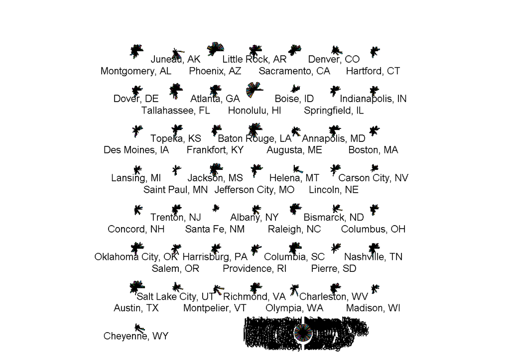

```r
colors = rainbow(50, s = 0.6, v = 0.75); # 50 colors for 50 states

# descriptive star plot to start
stars(whichX, len = 0.5, key.loc=c(12,2), draw.segments = TRUE);
```

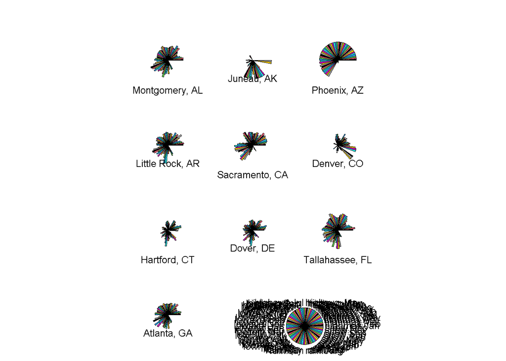

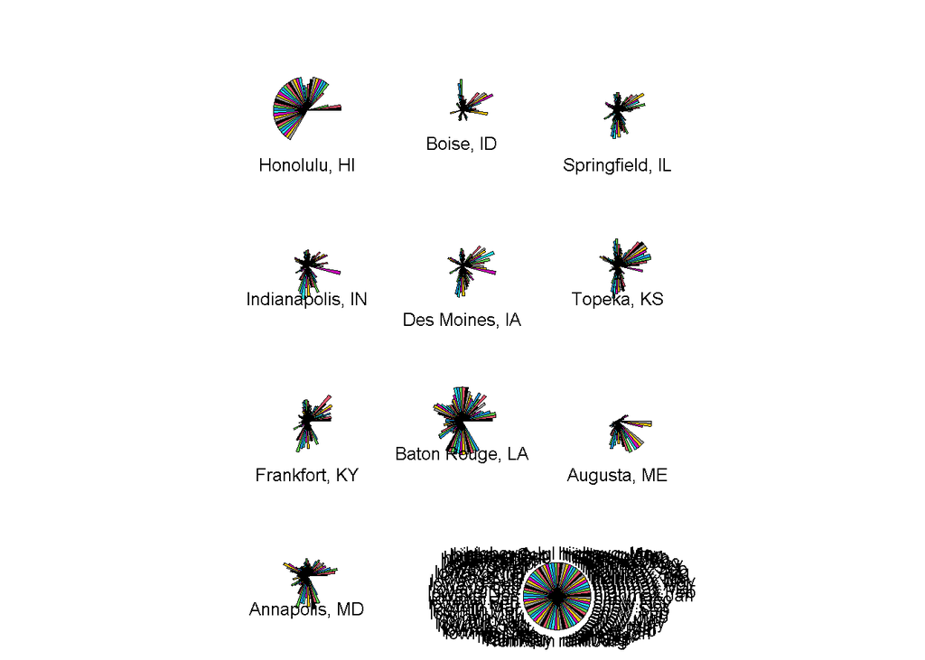

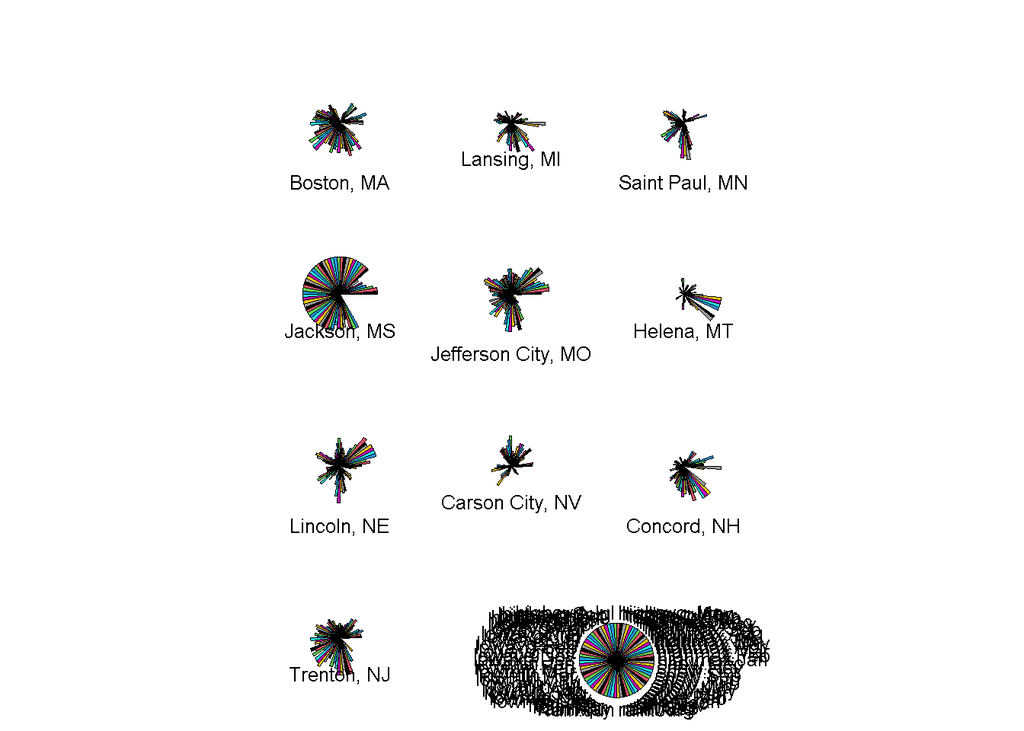

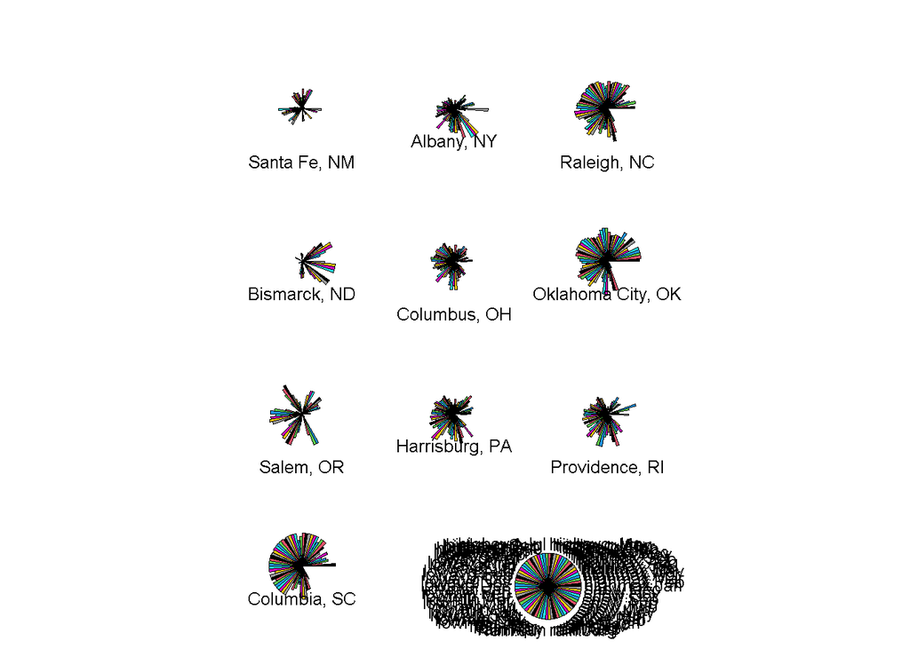

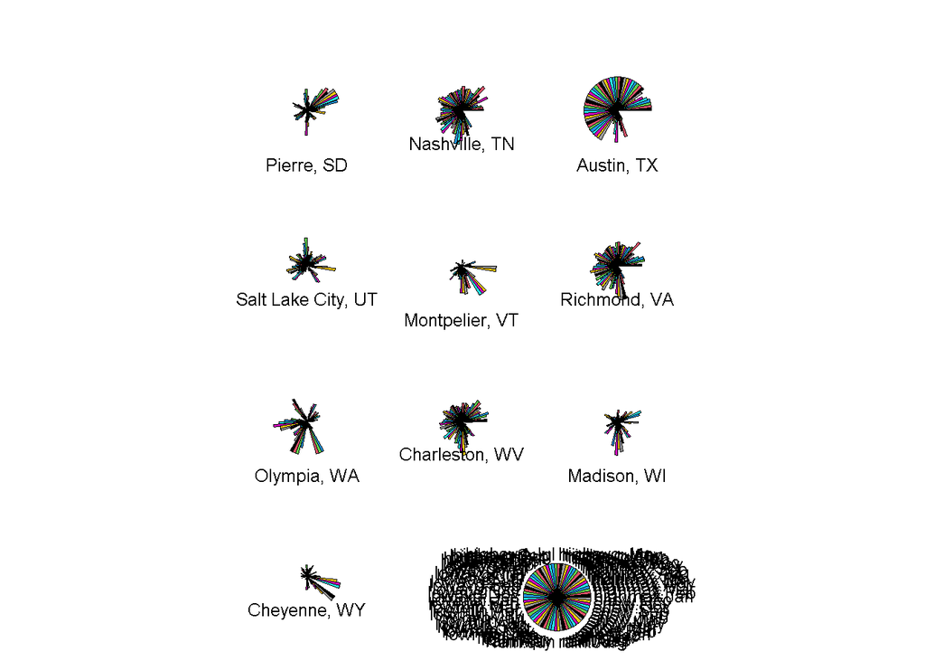

```r
## too busy, let's group them
x.start = 1;
x.end = 10;
for(i in 1:5)
  {
  stars( whichX[x.start:x.end,] ,
          len = 0.5, key.loc=c(6,2), draw.segments = TRUE);
  x.start = 1 + x.end;
  x.end = 10 + x.end;
  }
```

Above, you are just analyzing the general shapes. Which ones are “fuller” circles? Why?

Which ones are not very “full circles”? Why?

#### Computation of Clusters/Centroids

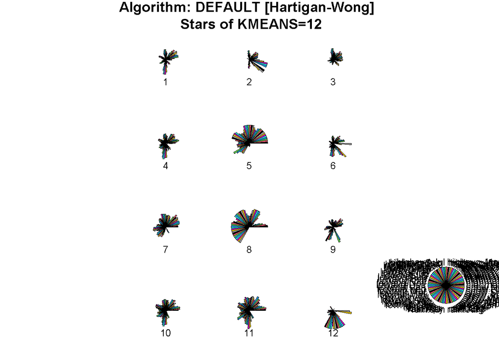

```r
k = 12;
iterations = 100;
number.starts = 100;

whichX.kmeans = kmeans(whichX, 12,
                    iter.max=iterations,
                    nstart = number.starts);  # default algorithm
stars(whichX.kmeans$centers, len = 0.5, key.loc = c(10, 3),
        main = "Algorithm: DEFAULT [Hartigan-Wong] \n Stars of KMEANS=12", draw.segments = TRUE);
```

#### Cluster Membership and Centroid Attributes

```r
membership = matrix( whichX.kmeans$cluster, ncol=1);
membership = membership[order(membership),];
membership = as.data.frame(membership);
        rownames(membership) = climate.df$labels;
        colnames(membership) = c("Cluster");

membership;
```

|  | Cluster |
| --- | --- |
| Montgomery, AL | 1 |
| Juneau, AK | 1 |
| Phoenix, AZ | 1 |
| Little Rock, AR | 1 |
| Sacramento, CA | 2 |
| Denver, CO | 2 |
| Hartford, CT | 2 |
| Dover, DE | 3 |
| Tallahassee, FL | 3 |
| Atlanta, GA | 3 |

[output cut: 40 more lines]

[output not shown]

```r
print( table(membership) ) ;
```

```
## membership
##  1  2  3  4  5  6  7  8  9 10 11 12
##  4  3  5 12  1  6  1  1  2  8  6  1
```

```r
# I believe in an older version of R these were called $centroids
attributes = as.data.frame( whichX.kmeans$centers );
    rownames(attributes) = paste0("Cluster.",1:12);
  attributes;
```

|  | highmax.Jan | highmax.Feb | highmax.Mar | highmax.Apr | highmax.May | highmax.Jun | highmax.Jul | highmax.Aug | highmax.Sep | highmax.Oct | highmax.Nov | highmax.Dec | highavg.Jan | highavg.Feb | highavg.Mar | highavg.Apr | highavg.May | highavg.Jun | highavg.Jul | highavg.Aug | highavg.Sep | highavg.Oct | highavg.Nov | highavg.Dec | lowavg.Jan | lowavg.Feb | lowavg.Mar | lowavg.Apr | lowavg.May | … |
| --- | --- | --- | --- | --- | --- | --- | --- | --- | --- | --- | --- | --- | --- | --- | --- | --- | --- | --- | --- | --- | --- | --- | --- | --- | --- | --- | --- | --- | --- | --- |
| Cluster.1 | 66.25000 | 73.75000 | 88.25000 | 95.25000 | 101.75000 | 106.5000 | 111.7500 | 109.2500 | 102.50000 | 94.75000 | 82.25000 | 71.75000 | 30.60000 | 35.52500 | 47.42500 | 61.07500 | 71.95000 | 81.45000 | 87.12500 | 84.97500 | 76.07500 | 62.22500 | 46.07500 | 32.87500 | 11.22500 | 15.65000 | 26.27500 | 38.02500 | 49.60000 | … |
| Cluster.2 | 65.33333 | 71.00000 | 78.66667 | 87.66667 | 96.00000 | 104.3333 | 106.3333 | 104.0000 | 99.66667 | 89.00000 | 76.33333 | 66.33333 | 32.06667 | 35.80000 | 45.36667 | 56.56667 | 66.73333 | 76.06667 | 84.60000 | 83.06667 | 72.16667 | 58.33333 | 43.06667 | 32.03333 | 11.06667 | 14.46667 | 22.70000 | 31.20000 | 41.23333 | … |
| Cluster.3 | 67.80000 | 73.80000 | 80.80000 | 88.60000 | 96.80000 | 104.0000 | 106.2000 | 104.4000 | 100.00000 | 90.60000 | 77.60000 | 71.60000 | 41.58000 | 46.44000 | 55.06000 | 62.56000 | 72.12000 | 82.26000 | 89.74000 | 87.76000 | 78.92000 | 65.84000 | 51.44000 | 41.30000 | 20.58000 | 23.84000 | 30.08000 | 35.66000 | 43.76000 | … |
| Cluster.4 | 74.83333 | 78.66667 | 89.41667 | 94.00000 | 98.58333 | 102.7500 | 107.5833 | 105.6667 | 102.91667 | 93.83333 | 83.41667 | 76.50000 | 37.86667 | 42.00000 | 51.77500 | 63.13333 | 72.58333 | 81.28333 | 85.49167 | 84.21667 | 77.08333 | 65.65000 | 53.80833 | 41.65000 | 21.45000 | 24.45000 | 32.06667 | 41.79167 | 51.41667 | … |
| Cluster.5 | 88.00000 | 92.00000 | 100.00000 | 105.00000 | 114.00000 | 122.0000 | 121.0000 | 117.0000 | 116.00000 | 107.00000 | 96.00000 | 87.00000 | 67.20000 | 70.70000 | 76.90000 | 85.20000 | 94.80000 | 103.90000 | 106.10000 | 104.40000 | 99.80000 | 88.50000 | 75.50000 | 66.00000 | 45.60000 | 48.70000 | 53.50000 | 60.20000 | 69.40000 | … |
| Cluster.6 | 65.66667 | 67.66667 | 85.50000 | 91.66667 | 96.00000 | 99.0000 | 102.0000 | 100.6667 | 97.33333 | 88.66667 | 78.00000 | 69.00000 | 28.65000 | 32.66667 | 42.46667 | 56.20000 | 67.73333 | 76.61667 | 81.05000 | 79.25000 | 71.26667 | 58.71667 | 46.01667 | 33.61667 | 11.80000 | 14.78333 | 23.55000 | 34.81667 | 44.83333 | … |
| Cluster.7 | 79.00000 | 80.00000 | 90.00000 | 98.00000 | 107.00000 | 112.0000 | 114.0000 | 112.0000 | 109.00000 | 102.00000 | 86.00000 | 72.00000 | 54.40000 | 61.20000 | 66.80000 | 72.70000 | 80.90000 | 87.90000 | 93.30000 | 92.20000 | 87.90000 | 77.90000 | 63.70000 | 54.30000 | 40.70000 | 43.70000 | 46.50000 | 49.00000 | 53.90000 | … |
| Cluster.8 | 88.00000 | 88.00000 | 89.00000 | 91.00000 | 93.00000 | 92.0000 | 94.0000 | 95.0000 | 95.00000 | 94.00000 | 93.00000 | 89.00000 | 80.10000 | 80.20000 | 81.20000 | 82.70000 | 84.60000 | 87.00000 | 87.90000 | 88.70000 | 88.60000 | 86.70000 | 83.90000 | 81.20000 | 66.30000 | 66.10000 | 67.70000 | 69.40000 | 70.90000 | … |
| Cluster.9 | 66.00000 | 72.50000 | 79.50000 | 90.50000 | 98.00000 | 101.5000 | 106.0000 | 106.0000 | 101.00000 | 91.50000 | 74.00000 | 68.00000 | 46.80000 | 50.45000 | 55.20000 | 60.00000 | 66.55000 | 72.25000 | 79.40000 | 80.05000 | 74.30000 | 62.15000 | 51.40000 | 45.20000 | 34.20000 | 33.70000 | 36.15000 | 38.65000 | 42.40000 | … |
| Cluster.10 | 79.75000 | 84.12500 | 91.75000 | 95.25000 | 98.75000 | 105.2500 | 106.6250 | 107.1250 | 103.25000 | 97.25000 | 86.12500 | 80.00000 | 47.97500 | 52.13750 | 60.56250 | 70.08750 | 78.06250 | 85.92500 | 89.68750 | 88.53750 | 81.80000 | 71.41250 | 61.10000 | 50.61250 | 29.77500 | 32.57500 | 39.53750 | 47.98750 | 57.33750 | … |

[output cut: 2 more lines]

[output not shown]

#### (10 points) Summarize Findings

- Identify which states share a common cluster.
- For a given cluster, what are its primary characteristics

```
-- WRITE SOMETHING HERE --
Cluster shapes in the star plot seem to correspond to the extremity of temperature range.  I.e Phoenix, AZ is very hot -- and so has a fuller circle shape -- where it is not a circle shape and "blank" corresponds to their winter temperatures which are closer to 0 degrees.  I.e. I think that the ones with not "full circles" are cities that have temperature ranges closes to 0 degrees Fahrenheit.  Those with bigger circles indicate higher temperatures in those corresponding months.

Note: I ran the cluster code twice, and I'm not sure why, but the data seems to cluster differently between the two times. I am entering cluster data for the one of these iterations. (K-means can generate random results)

Cluster 1: Montgomery, AL; Juneau, AK; Phoenix, AZ; Little Rock, AK

Cluster 2: Sacramento, CA; Denver, CO; Hartford, CT

Cluster3: Dover, DE; Tallahssee, FL; Atlanta, GA; Honolulu, HI; Boise, ID

Cluster 4: Springfield, IL; Indianapolis, IN; Des Moines, IA; Topeka, KS; Frankfort, KY; Baton Rouge, LA; Augusta, ME; Annapolis, MD; Boston, MA; Lansing, MI; Saint Paul, MN; Jackson, MS

Cluster 5: Jefferson City, MO

Cluster 6: Helena, MT; Lincoln, NE; Carson City, NV; Concord, NH; Trenton, NJ; Santa Fe, NM

Cluster 7: Albany, NY

Cluster 8: Raleigh, NC

Cluster 9: Bismarck, ND; Columbus, OH

Cluster 10: Oklahoma City, OK; Salem, OR; Harrisburg, PA; Providence, RI; Columbia, SC; Pierre, SD; Nashville, TN; Austin, TX

Cluster 11: Salt Lake City, UT; Montpelier, VT; Richmond, VA; Olympia, WA; Charleston, WV; Madison, WI

Cluster 12: Cheyenne, WY

I cannot find anything common in the clusters.  K-means is generated by assigning states to clusters randomly, calculate the centroid/mean of each cluster, and then assigning each state to the closest cluster.  It iterates between the two steps until the clusters do not change.  So, theoretically, what these clusters have in common are the closest to each other in terms of temperature.

However, I don't equate Alaska temperatures being close to Alabama, Arizona, or Arkansas, so ....

I just noticed that the clusters are in alphabetical order.  Primary characteristic is the state alphabetical order.
```

[ Summarize your k-means findings for 12 clusters.]

## (15 points) Correlation

Correlation, like distance, is an important feature of multivariate analysis. So let’s review some basic correlation related to our climate data. For simplicity, let’s consider “Record High Temperature” and “Record Low Temperature” and see how they correlate with other factors we have gathered from Wikipedia.

Recall, in this table, “Jan-Dec” are different months of the same temperature variable.

```r
library(Hmisc); # p-values for correlation

high = subsetDataFrame(climate, c("key", "units"), "==", c("Record high F (C)",1));
high = merge(high, capitals, by=c("capital","state"));

high.X = high[,c(5:18,21)]; # numeric data
high.cor = round( cor(high.X), digits=2);
# high.cor.p = rcorr(as.matrix(high.X), type="pearson");  # p-values for statistical significance ... # str(high.cor.p);

# examine July (idx = 7)

as.data.frame( high.cor ) ; # so it will render nicely in RStudio
```

|  | Jan | Feb | Mar | Apr | May | Jun | Jul | Aug | Sep | Oct | Nov | Dec | latitude | longitude | population.2019.est |
| --- | --- | --- | --- | --- | --- | --- | --- | --- | --- | --- | --- | --- | --- | --- | --- |
| Jan | 1.00 | 0.92 | 0.76 | 0.57 | 0.43 | 0.39 | 0.25 | 0.41 | 0.62 | 0.71 | 0.89 | 0.94 | -0.83 | 0.07 | 0.40 |
| Feb | 0.92 | 1.00 | 0.80 | 0.63 | 0.62 | 0.53 | 0.45 | 0.59 | 0.74 | 0.79 | 0.89 | 0.89 | -0.80 | 0.01 | 0.42 |
| Mar | 0.76 | 0.80 | 1.00 | 0.87 | 0.73 | 0.56 | 0.53 | 0.67 | 0.76 | 0.82 | 0.89 | 0.81 | -0.68 | 0.39 | 0.36 |
| Apr | 0.57 | 0.63 | 0.87 | 1.00 | 0.82 | 0.68 | 0.65 | 0.75 | 0.79 | 0.81 | 0.76 | 0.65 | -0.49 | 0.34 | 0.35 |
| May | 0.43 | 0.62 | 0.73 | 0.82 | 1.00 | 0.83 | 0.85 | 0.85 | 0.86 | 0.81 | 0.65 | 0.46 | -0.40 | 0.08 | 0.38 |
| Jun | 0.39 | 0.53 | 0.56 | 0.68 | 0.83 | 1.00 | 0.90 | 0.86 | 0.87 | 0.78 | 0.56 | 0.41 | -0.30 | 0.01 | 0.48 |
| Jul | 0.25 | 0.45 | 0.53 | 0.65 | 0.85 | 0.90 | 1.00 | 0.91 | 0.86 | 0.73 | 0.46 | 0.27 | -0.15 | 0.02 | 0.31 |
| Aug | 0.41 | 0.59 | 0.67 | 0.75 | 0.85 | 0.86 | 0.91 | 1.00 | 0.90 | 0.78 | 0.57 | 0.46 | -0.29 | 0.04 | 0.31 |
| Sep | 0.62 | 0.74 | 0.76 | 0.79 | 0.86 | 0.87 | 0.86 | 0.90 | 1.00 | 0.88 | 0.74 | 0.65 | -0.46 | 0.07 | 0.44 |
| Oct | 0.71 | 0.79 | 0.82 | 0.81 | 0.81 | 0.78 | 0.73 | 0.78 | 0.88 | 1.00 | 0.86 | 0.72 | -0.67 | 0.14 | 0.39 |

[output cut: 5 more lines]

[output not shown]

```r
high.cor.july = high.cor[,7];
high.cor.july;
```

```
##                 Jan                 Feb                 Mar                 Apr
##                0.25                0.45                0.53                0.65
##                 May                 Jun                 Jul                 Aug
##                0.85                0.90                1.00                0.91
##                 Sep                 Oct                 Nov                 Dec
##                0.86                0.73                0.46                0.27
##            latitude           longitude population.2019.est
##               -0.15                0.02                0.31
```

[output not shown]

Describe the correlation of July in “Record high F (C)” to the other numeric factors printed above.

- July perfectly correlates with July (1.00). This correlation is positive and very strong. This is because they are the same data.
- With the months, you can note each, or plot a trend showing them, and discussing them briefly as a trend.
- latitude is a measure of north/south, so be certain to apply the correlation value with some meaning. be certain you know which direction is positive or negative to correctly interpret the sign of the correlation.
- longitude is a measure of east/west, so be certain …
- population is the size of the city
- intuitively, which months do you think correlate most with latitude for this data? which correlate the least? is the correlation always the same sign (positive/negative), or does it change? [You can use the dataframe output to do this analysis, or create your own subset]

```r
library(Hmisc); # p-values for correlation

low = subsetDataFrame(climate, c("key", "units"), "==", c("Record low F (C)",1));
low = merge(low, capitals, by=c("capital","state"));

low.X = low[,c(5:18,21)]; # numeric data
low.cor = round( cor(low.X), digits=2);
# low.cor.p = rcorr(as.matrix(low.X), type="pearson");  # p-values for statistical significance ... # str(low.cor.p);

# examine Jan (idx = 1)

as.data.frame( low.cor ) ; # so it will render nicely in RStudio
```

|  | Jan | Feb | Mar | Apr | May | Jun | Jul | Aug | Sep | Oct | Nov | Dec | latitude | longitude | population.2019.est |
| --- | --- | --- | --- | --- | --- | --- | --- | --- | --- | --- | --- | --- | --- | --- | --- |
| Jan | 1.00 | 0.95 | 0.93 | 0.92 | 0.89 | 0.80 | 0.74 | 0.77 | 0.90 | 0.87 | 0.91 | 0.97 | -0.72 | -0.33 | 0.34 |
| Feb | 0.95 | 1.00 | 0.94 | 0.92 | 0.86 | 0.75 | 0.70 | 0.72 | 0.88 | 0.86 | 0.92 | 0.95 | -0.64 | -0.36 | 0.37 |
| Mar | 0.93 | 0.94 | 1.00 | 0.92 | 0.85 | 0.73 | 0.71 | 0.72 | 0.85 | 0.85 | 0.90 | 0.93 | -0.69 | -0.31 | 0.32 |
| Apr | 0.92 | 0.92 | 0.92 | 1.00 | 0.91 | 0.82 | 0.78 | 0.81 | 0.93 | 0.89 | 0.89 | 0.92 | -0.71 | -0.25 | 0.37 |
| May | 0.89 | 0.86 | 0.85 | 0.91 | 1.00 | 0.93 | 0.88 | 0.88 | 0.95 | 0.93 | 0.89 | 0.91 | -0.72 | -0.12 | 0.35 |
| Jun | 0.80 | 0.75 | 0.73 | 0.82 | 0.93 | 1.00 | 0.92 | 0.91 | 0.88 | 0.82 | 0.81 | 0.82 | -0.75 | -0.05 | 0.39 |
| Jul | 0.74 | 0.70 | 0.71 | 0.78 | 0.88 | 0.92 | 1.00 | 0.96 | 0.87 | 0.77 | 0.75 | 0.78 | -0.75 | 0.09 | 0.46 |
| Aug | 0.77 | 0.72 | 0.72 | 0.81 | 0.88 | 0.91 | 0.96 | 1.00 | 0.87 | 0.77 | 0.75 | 0.79 | -0.80 | 0.02 | 0.46 |
| Sep | 0.90 | 0.88 | 0.85 | 0.93 | 0.95 | 0.88 | 0.87 | 0.87 | 1.00 | 0.94 | 0.92 | 0.91 | -0.72 | -0.09 | 0.40 |
| Oct | 0.87 | 0.86 | 0.85 | 0.89 | 0.93 | 0.82 | 0.77 | 0.77 | 0.94 | 1.00 | 0.93 | 0.90 | -0.66 | -0.04 | 0.32 |

[output cut: 5 more lines]

[output not shown]

```r
low.cor.january = low.cor[,1];
low.cor.january;
```

```
##                 Jan                 Feb                 Mar                 Apr
##                1.00                0.95                0.93                0.92
##                 May                 Jun                 Jul                 Aug
##                0.89                0.80                0.74                0.77
##                 Sep                 Oct                 Nov                 Dec
##                0.90                0.87                0.91                0.97
##            latitude           longitude population.2019.est
##               -0.72               -0.33                0.34
```

Describe the correlation of January in “Record low F (C)” to the other numeric factors printed above.

[output not shown]

Similar to “high” writeup, but for the “low” data.

## “So What” is DATA ANALYSIS?

In the social sciences (e.g., Karl Weick), the concept of “sense making” refers to “the process by which people give meaning to their collective experiences”. I have used this framework in my high-technology innovation research (See Figure 1 of http://www.mshaffer.com/arizona/pdf/LoneGenius.pdf, my rubric concept comes from learning-theory growth models: Nascent, Adolescent, Mature.)

This final topic is reflective: we are thinking about how we think.

### Statistics

The syllabus defined statistics as “the discipline that concerns the collection, organization, analysis, interpretation and presentation of data.” (See https://en.wikipedia.org/wiki/Statistics)

There are 5 elements mentioned: collection, organization, analysis, interpretation, and presentation of “data”. Are those equally weighted? That is, should we devote 20% of our time to each of those? Now, consider the “analysis” stage. I have suggested there are two camps: exploratory and confirmatory data analysis. Are those equally weighted? That is, should we devote 50% of our time to each of those? Now, in an “equally-likely” scenario, we would have.

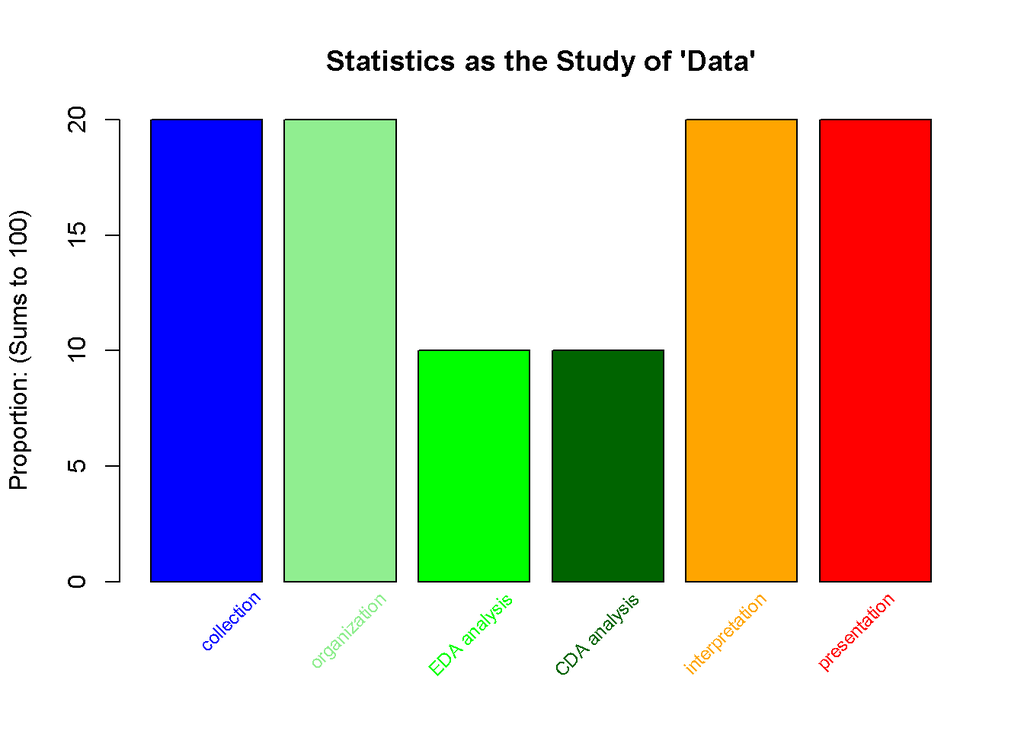

```r
x = c(20,20,10,10,20,20);
x.labels = c("collection", "organization", "EDA analysis", "CDA analysis", "interpretation", "presentation");
x.colors = c("blue", "lightgreen", "green", "darkgreen", "orange", "red");

barplot(x,
        col = x.colors,
        ylim = c(0, 20),
        ylab = "Proportion: (Sums to 100)",
        main="Statistics as the Study of 'Data'");


text(1.14* (1:6), par("usr")[3], col = x.colors, labels = x.labels, srt = 45, adj = c(1.1,1.1), xpd = TRUE, cex=.75);
```

### Data Analytics

[figure not shown]

**Source: https://data-analytics.wsu.edu/197-2/** (Accessed October 2010)

“Data analytics is the application of powerful new methods—drawn from computer science, mathematics and statistics, and domain sciences—to collect, curate, analyze, discover and communicate knowledge from ‘big data’.” https://data-analytics.wsu.edu/ (Accessed October 2010)

#### Importance of ‘Data’

I love data.

I also love math/physics. I also love exploratory data analysis. I also love computational statistics or statistical computing https://en.wikipedia.org/wiki/Computational_statistics. I also love thinking about developing the one graphic to summarize data most effectively.

#### Apprenticeship as Learning a Trade

The idea of sharing in the learning process is an important aspect of the apprenticeship model. You are learning a trade (data analytics). I have experience in this trade. My job as the instructor is to provide you with a variety of “situated-learning” experiences To help you understand the nature of the trade. This exam is an example of such an experience.

#### Tools of the Trade

Below are the core requirements for the data analytics program:

- Calculus and linear algebra (10 credits)
- Computer science fundamentals (11 credits)
- Machine learning and data management (9 credits)
- Statistics (15 credits)
- Data analytics introduction, ethics & project-focused * capstone experience (9 credits)

These are not the tools of the trade, but hopefully, they introduce you to key tools of the trade. What exactly are tools of the trade? [You will have an opportunity to write a response below.]

#### Dimensional Reduction, an Axiomatic View

This video was recently shared with me that highlights some distinctions among persons practicing various forms of data analysis https://www.youtube.com/watch?v=uHGlCi9jOWY. As an orthogonal projection, I would create two axes. On the horizontal axis (x-axis), I would place “theory of data” to the left and “application of data” toward the right. On the vertical axis (y-axis), I would place “care for data integrity” at the top and “less care for data integrity” at the bottom.

#### Skills of the Trade

As someone that is coming from industry, having hired young people like you out of Computer Science, Electrical-Computer Engineering, I have opinions related to skills of the trade.

- Can you acquire an appreciation for “data intimacy”?
- Can you track and document how data is curated?
- Can you track and document the analyses you perform? Can you recreate them? Do you have basic version-control protocols in place?
- Can you view data from multiple perspectives and synthesize those perspectives to identify the central them of the data? Can you be objective? Can you try and identify objective metrics to enlighten your understanding about the essence of data?
- Can you experiment with different visualizations in search of an optimal “one graphic” result? Do you have practice using various visualization tools? Can you comprehend which visualization tool is appropriate for messaging (communicating results) to a particular audience?
- Can you communicate and defend your findings to a particular audience? Are your communications professional? Is the final work product both simple and comprehensive: simple in its summary findings and comprehensive in its ability to be replicated and audited as necessary.

## (20 points) YOUR OPINION OF DATA ANALYTICS

[This is worth 20 points.

Specifically, address:

1. what proportion of “statistics” should be divided among: collection, organization, analysis, interpretation, and presentation of “data” … providing a `barplot` of your opinion within your response would seem appropriate

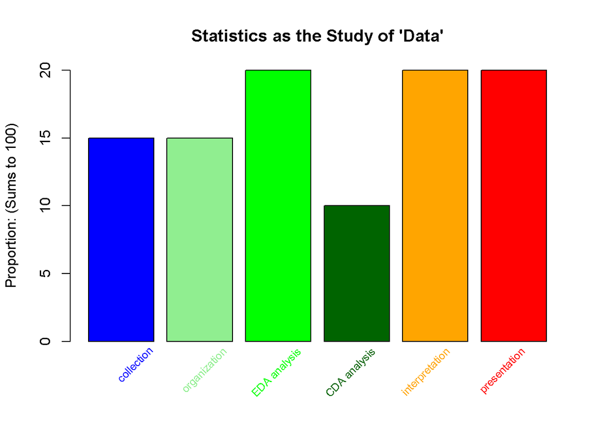

```r
x = c(15,15,20,10,20,20);  ## change these values and discuss ...
x.labels = c("collection", "organization", "EDA analysis", "CDA analysis", "interpretation", "presentation");
x.colors = c("blue", "lightgreen", "green", "darkgreen", "orange", "red");

barplot(x,
        col = x.colors,
        ylim = c(0, max(x)),
        ylab = "Proportion: (Sums to 100)",
        main="Statistics as the Study of 'Data'");


text(1.14* (1:6), par("usr")[3], col = x.colors, labels = x.labels, srt = 45, adj = c(1.1,1.1), xpd = TRUE, cex=.75);
```

2. what tools of the trade should you be acquiring from the core courses? how are you doing in that acquisition process (e.g., tool X is … and right now I feel like my understanding/proficiency of tool X … ) …
3. utilize the provided `plot` script to place the coure-course categories on the proposed x-y graph related to analytics practice (Applied vs Theoretical) and care of data integrity (Great Care vs Little Care) … Also place your personal assessment on the plot script provided
4. evaluate your skill-level on the six “skills of the trade”: Emerging (Nascent), Developing (Adolescent), Mastering (Mature). explain your evaluation and include other important skills you believe are relevant that are not included
5. Any other comments you would like to share.

]

```
1) This one was hard for me, and depending on where I put an emphasis on, I would have weighted them slightly differently.  I think it's all important, and also the lines can be blurry between these categories. For example, "collection" and "organization" are closely aligned -- the more organized the data collection, the less time you have to organize it into a usable format.  EDA and CDA also go hand in hand -- perhaps in pure statistics, CDA would be more heavily weighted than EDA, however, even in "pure" statistics, objectivity is important, and EDA is more weighted with objectivity.  Interpretation goes with EDA, and then blurs into Presentation category.  Interpretation is needed as the result of analysis, and then the efficacy of that interpretation is dependent on the quality of presentation.  I kept Interpretation and Presentation as high as it was originally plotted because I think that this is the step that most people place the lowest value in, and while it isn't as "hard" as "coding" or "math", it is harder to do effectively (not for technical co-workers, but to effectively communicate your interpretation to the non-technical).  And while I know how importatnt "presentation" is, I do tend to spend less time on it (and my courses reflect this lack of emphasis as well) than other areas (such as math, programming, and statistics, all of which focus on collection to interpretation).

2) I'm not sure what is a tool of the trade, but I see data analyst as a blend of computer programmer and statistician. In most industries, since most need to generate profits, a data analyst also needs to be able to connect information to the company in a way to either generate revenue, or save money. But at the end of the day, it's tied to money. The last is more esoteric, and would require some general knowledge of the specific industry -- several years or so working for a company would be able to provide that.

Tool:: Programming -->provided by Python and Statistics classes.

Right now I feel like my understanding/proficiency of X is: developing.  I've taken several courses (2 in Java, 1 right now in Python, 2 right now in R). I may do terrible in 2 hour timed exams without the resources of the Internet to correct my syntax, but I have taken to Python and R far easier than I originally anticipated from Java, because the core concepts are there.  What took me surprise in the beginning of this course was how differently dataframes are processed and accessed vs arrays.  I'm still a little weak in OOP -- but so much better than I was a year ago. But with programming, there are times I dream about the assignment I can't solve.

Tool::Statistics -->provided by statistics classes

Right now I feel like my understanding/proficiency of X is: emerging. Again, this is my first "real" semester of statistics. Up to this point, my classes have been in math and programming (not counting the MIS classes). I took Intro to Statistics for Science/Engineers (nothing like the Intro to Statistics classes I took (twice) many years ago btw!) over the summer, and that is it. How am I doing in the acquisition process...?  Not sure.  Right now, I feel like it's very difficult to teach statistics to students -- things can be contextual, and fluid. Still, I did like how this midterm was constructed -- was quite contextually appropriate for a data analytics major.  In my other classes, I'm to perform all these regression tests and then make comments on the values I get or the plots I generate and that is the hardest part for me.  I feel like I'm guessing all the time.  Maybe it's because I don't have as good of a background in statistics as I feel like I had in programming (where I had to take a specific progression of classes), vs statistics (where I had basically no progression).

Tool:: Tie the two together along with some awesome visualizations and quality control --> provided by experience

Very low proficiency -- but projects and assignments dedicated to this arena will probably round me out.  Also, I've had a friend offer to show me Github but I never "had" to, so classes like this that force me to dip my toe (and walk me through on how to do it via lectures) are important!  But in general, I think a synthesis will happen best in an internship/job scenario.  Everyone I talk to says corporate jobs are nothing like their college degree courses.

3) plot: I evaluated myself as such as how I imagine myself in the field. I assume I'll be working in a corporate environment, and possibly needing to figure out where my boundaries are in terms of data provenance and the company. I believe in data provenance, but I also am not arrogant enough to assume I will not be faced with some ethical choices.  A manager told my husband to have a line in the sand that he will not cross when it comes to ethics and company wants. He's told me about people who bend far too easily "yes-men" and the rare few that are so inflexible regarding their strict ethical code that they are not able to stay in a job for more than a year (which isn't as bad of a thing in the Bay Area as it might be in other areas but that's not the point...) Where do I stand?  I don't know.  I will find out.  Balance and compromise between ethics and reality....(but I will NOT be working for Facebook, even IF they would even hire me which I doubt, but will never find out as I will never apply there).  I do imagine that I will be more towards the applied data practice -- I do not like math, and I've done it enough to know I never will.  I have not done enough statistics yet to know whether I "like" it or not.

It's hard for me to evaluate the core course categories in terms of data integrity.  In essence, I feel as if core courses (as not being human), do not care at all for data integrity and all should be scored as "little care for data integrity".  It is the human that cares or should care.

4) An appreciation for "data intimacy": Emerging
Track and document how data is curated: Emerging
Track and document analyses? Reproducibility? Basic version-control protocols: Emerging
View data from multiple perspectives and synthesize to identify the central theme: Emerging
Experiment with different visualization in search of optimal graphics: Emerging
Presentation skills: Emerging

I evaluated myself as "emerging" for all six areas. Of all of these, I think I have a "mature" appreciation for data intimacy, but that none of is in in a concrete form -- which the following two skills (track and document data collection and analysis) seems to reflect. At this time, I have done very little statistical analyses, or collection. This semester is my first. This class is the first to discuss version control using Github, Dropbox, json files, etc. This is the first to discuss data collection --granted, you've ended up creating the code for the data scraping, but you are scraping from the Internet. My sister has mentioned that she's never scraped the Internet before -- her datasets are provided to her by her companies.  This is my primary reason for categorizing myself as emergent.

I feel that by the end of Spring 2021 (where I will be taking at least two more stats classes plus the next programming course, assuming I don't fail), I will feel more confident in describing my skills as developing!

However, as Albert Einstein said, "As our circle of knowledge expands, so does the circumference of darkness surrounding it."

5) I like the more philosophical/opinionated parts of this class.

I agree with the "one graphic".  Not so much as "one", but my husband's (who is a systems engineer by trade but does enjoy data more than most engineers) opinion on the importance of a well-done graphic is, and how humans are able to process information visually faster than any other means.

I'm surprised at how little coding there is in this midterm, and how much analysis there is.  Granted, at this time, I have not done the clustering/correlation categories of this midterm. In some ways, this makes it an "easier" test, but unlike my math classes, which has a "right" answer, statistics (no matter how the YouTube video rapped that it was precisely driven unlike data science, is open to interpretation.  This fluidity makes it hard for me, like I am floundering in murky water.  Given enough times being thrust into situations like this through my statistics courses and future employment, I think I will start to be able to become more sure-footed.  It's good to be forced to interpret the analysis....because that's a very important part of the whole world of data analytics.

This is one of my pet peeves with statistics/data analysis.  The murkiness.  In calculus, there is a right answer.  In programming, there are clear objectives to meet -- how you get there can be varied but objectives are clear.  Even in the other statistics class taking right now, statistics is about "reading" different visualizations or interpreting p-values, t-test values, MSE errors, etc etc, and then, sometimes, it's by context. I wonder if there is no easy way to teach "how to interpret visualizations/values" because it's been rather confusing for me.  Perhaps it's just taking the time to practice enough....

This was an exhausting midterm despite the low level of coding in it.  Maybe it was the length/depth of it. I did enjoy the philosophical parts and I found the topics within interesting by tying the "real" world with it (using actual imdb data, indeed.com data, ability to customize the distance boxes to different locations, etc etc. (And I'm still not done -- I left the clustering and correlation part for last as I needed a "break" and did this section).
```

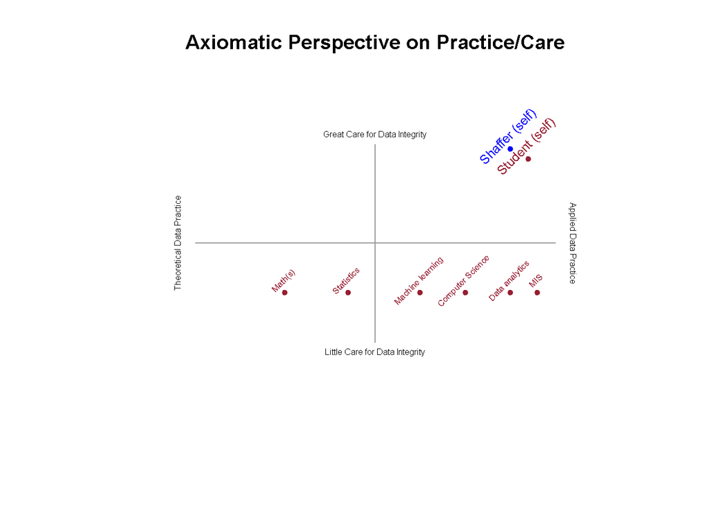

```r
# x is -1 for perfectly theoretical
# x is 1 for perfectly applied

# y is -1 for no care whatsoever for data integrity
# y is 1 is perfect care for data integrity

########################### basic plot setup #####
plot(0,0, col="white",
  ylim=c(-1.5,1.5), xlim=c(-1.5,1.5),
  xlab = "",
  ylab = "",
  xaxt = 'n', bty = 'n', yaxt = 'n',
  main = "Axiomatic Perspective on Practice/Care",
  );
segments(-1,0,1,0, col="#999999");
segments(0,-1,0,1, col="#999999");
text(-1.1,0, "Theoretical Data Practice", cex=0.5, srt = 90);
text(1.1,0, "Applied Data Practice", cex=0.5, srt = -90);
text(0,1.1, "Great Care for Data Integrity", cex=0.5, srt = 0);
text(0,-1.1, "Little Care for Data Integrity", cex=0.5, srt = 0);
########################### basic plot setup #####


########################### you can add elements here #####
## this point represents the professor's self-perception
points(0.75, 0.95, pch=20, col="blue");
text(0.75, 0.95, "Shaffer (self)", col="blue", cex=0.75, srt = 45, pos=3);

#############  TODO ###### ... maybe change color for each data point

#https://brand.wsu.edu/visual/colors/
#crimson = #981e32
# you need to change the x,y from 0,0 ...
# you can change col ... cex (font size), srt (angle), and pos = 1,2,3,4
#
points(.85, .85, pch=20, col="#981e32");
text(0.85, 0.85, "Student (self)", col="#981e32", cex=0.75, srt = 45, pos=3);
#
# ## evaluate the Course Categories of Tools of the Trade
# ## give them a score
#
points(-.5, -.5, pch=20, col="#981e32");
text(-.5, -.5, "Math(s)", col="#981e32", cex=0.5, srt = 45, pos=3);
#
#
points(.5, -.5, pch=20, col="#981e32");
text(.5, -.5, "Computer Science", col="#981e32", cex=0.5, srt = 45, pos=3);
#
points(.25, -.5, pch=20, col="#981e32");
text(.25, -.5, "Machine learning", col="#981e32", cex=0.5, srt = 45, pos=3);
#
points(-.15, -.5, pch=20, col="#981e32");
text(-.15, -.5, "Statistics", col="#981e32", cex=0.5, srt = 45, pos=3);
#
points(.75, -.5, pch=20, col="#981e32");
text(.75, -.50, "Data analytics", col="#981e32", cex=0.5, srt = 45, pos=3);
#
# # You have a track (e.g., Business)
points(.9, -.5, pch=20, col="#981e32");
text(.9, -.50, "MIS", col="#981e32", cex=0.5, srt = 45, pos=3);
```